# Risk Factor Analysis

## Outcome Variable

**Outcome Variable:** haz

## Predictor Variables

**Intervention Variable:** pers_wast

**Adjustment Set:**

- arm
- sex
- brthmon
- W_mage
- meducyrs
- hhwealth_quart
- W_nrooms
- month
- W_parity
- delta_W_mage
- delta_meducyrs
- delta_hhwealth_quart
- delta_W_nrooms
- delta_month
- delta_W_parity

## Stratifying Variables

The analysis was stratified on these variable(s):

- agecat
- studyid
- country

## Data Summary

| agecat | studyid | country | pers_wast | n_cell | n | outcome_variable |
| --- | --- | --- | --- | --- | --- | --- |
| Birth | CMC-V-BCS-2002 | INDIA | 0 | 80 | 92 | haz |
| Birth | CMC-V-BCS-2002 | INDIA | 1 | 12 | 92 | haz |
| Birth | CMIN | BANGLADESH | 0 | 16 | 18 | haz |
| Birth | CMIN | BANGLADESH | 1 | 2 | 18 | haz |
| Birth | CONTENT | PERU | 0 | 2 | 2 | haz |
| Birth | CONTENT | PERU | 1 | 0 | 2 | haz |
| Birth | EE | PAKISTAN | 0 | 224 | 240 | haz |
| Birth | EE | PAKISTAN | 1 | 16 | 240 | haz |
| Birth | GMS-Nepal | NEPAL | 0 | 521 | 585 | haz |
| Birth | GMS-Nepal | NEPAL | 1 | 64 | 585 | haz |
| Birth | IRC | INDIA | 0 | 319 | 387 | haz |
| Birth | IRC | INDIA | 1 | 68 | 387 | haz |
| Birth | Keneba | GAMBIA | 0 | 1374 | 1419 | haz |
| Birth | Keneba | GAMBIA | 1 | 45 | 1419 | haz |
| Birth | MAL-ED | BANGLADESH | 0 | 220 | 229 | haz |
| Birth | MAL-ED | BANGLADESH | 1 | 9 | 229 | haz |
| Birth | MAL-ED | BRAZIL | 0 | 65 | 65 | haz |
| Birth | MAL-ED | BRAZIL | 1 | 0 | 65 | haz |
| Birth | MAL-ED | INDIA | 0 | 43 | 45 | haz |
| Birth | MAL-ED | INDIA | 1 | 2 | 45 | haz |
| Birth | MAL-ED | NEPAL | 0 | 26 | 27 | haz |
| Birth | MAL-ED | NEPAL | 1 | 1 | 27 | haz |
| Birth | MAL-ED | PERU | 0 | 233 | 233 | haz |
| Birth | MAL-ED | PERU | 1 | 0 | 233 | haz |
| Birth | MAL-ED | SOUTH AFRICA | 0 | 111 | 113 | haz |
| Birth | MAL-ED | SOUTH AFRICA | 1 | 2 | 113 | haz |
| Birth | MAL-ED | TANZANIA, UNITED REPUBLIC OF | 0 | 123 | 123 | haz |
| Birth | MAL-ED | TANZANIA, UNITED REPUBLIC OF | 1 | 0 | 123 | haz |
| Birth | PROVIDE | BANGLADESH | 0 | 516 | 539 | haz |
| Birth | PROVIDE | BANGLADESH | 1 | 23 | 539 | haz |

[output cut: 70 more lines]

The following strata were considered:

- agecat: 24 months, studyid: CMC-V-BCS-2002, country: INDIA
- agecat: 24 months, studyid: CMIN, country: BANGLADESH
- agecat: 24 months, studyid: CONTENT, country: PERU
- agecat: 24 months, studyid: EE, country: PAKISTAN
- agecat: 24 months, studyid: GMS-Nepal, country: NEPAL
- agecat: 24 months, studyid: IRC, country: INDIA
- agecat: 24 months, studyid: Keneba, country: GAMBIA
- agecat: 24 months, studyid: MAL-ED, country: BANGLADESH
- agecat: 24 months, studyid: MAL-ED, country: BRAZIL
- agecat: 24 months, studyid: MAL-ED, country: INDIA
- agecat: 24 months, studyid: MAL-ED, country: NEPAL
- agecat: 24 months, studyid: MAL-ED, country: PERU
- agecat: 24 months, studyid: MAL-ED, country: SOUTH AFRICA
- agecat: 24 months, studyid: MAL-ED, country: TANZANIA, UNITED REPUBLIC OF
- agecat: 24 months, studyid: PROVIDE, country: BANGLADESH
- agecat: 24 months, studyid: TanzaniaChild2, country: TANZANIA, UNITED REPUBLIC OF
- agecat: 6 months, studyid: CMC-V-BCS-2002, country: INDIA
- agecat: 6 months, studyid: CMIN, country: BANGLADESH
- agecat: 6 months, studyid: CONTENT, country: PERU
- agecat: 6 months, studyid: EE, country: PAKISTAN
- agecat: 6 months, studyid: GMS-Nepal, country: NEPAL
- agecat: 6 months, studyid: Guatemala BSC, country: GUATEMALA
- agecat: 6 months, studyid: IRC, country: INDIA
- agecat: 6 months, studyid: Keneba, country: GAMBIA
- agecat: 6 months, studyid: MAL-ED, country: BANGLADESH
- agecat: 6 months, studyid: MAL-ED, country: BRAZIL
- agecat: 6 months, studyid: MAL-ED, country: INDIA
- agecat: 6 months, studyid: MAL-ED, country: NEPAL
- agecat: 6 months, studyid: MAL-ED, country: PERU
- agecat: 6 months, studyid: MAL-ED, country: SOUTH AFRICA
- agecat: 6 months, studyid: MAL-ED, country: TANZANIA, UNITED REPUBLIC OF
- agecat: 6 months, studyid: PROVIDE, country: BANGLADESH
- agecat: 6 months, studyid: ResPak, country: PAKISTAN
- agecat: 6 months, studyid: TanzaniaChild2, country: TANZANIA, UNITED REPUBLIC OF
- agecat: Birth, studyid: CMC-V-BCS-2002, country: INDIA
- agecat: Birth, studyid: CMIN, country: BANGLADESH
- agecat: Birth, studyid: CONTENT, country: PERU
- agecat: Birth, studyid: EE, country: PAKISTAN
- agecat: Birth, studyid: GMS-Nepal, country: NEPAL
- agecat: Birth, studyid: IRC, country: INDIA
- agecat: Birth, studyid: Keneba, country: GAMBIA
- agecat: Birth, studyid: MAL-ED, country: BANGLADESH
- agecat: Birth, studyid: MAL-ED, country: BRAZIL
- agecat: Birth, studyid: MAL-ED, country: INDIA
- agecat: Birth, studyid: MAL-ED, country: NEPAL
- agecat: Birth, studyid: MAL-ED, country: PERU
- agecat: Birth, studyid: MAL-ED, country: SOUTH AFRICA
- agecat: Birth, studyid: MAL-ED, country: TANZANIA, UNITED REPUBLIC OF
- agecat: Birth, studyid: PROVIDE, country: BANGLADESH
- agecat: Birth, studyid: ResPak, country: PAKISTAN

### Dropped Strata

Some strata were dropped due to rare outcomes:

- agecat: Birth, studyid: CMIN, country: BANGLADESH
- agecat: Birth, studyid: CONTENT, country: PERU
- agecat: Birth, studyid: MAL-ED, country: BRAZIL
- agecat: Birth, studyid: MAL-ED, country: INDIA
- agecat: Birth, studyid: MAL-ED, country: NEPAL
- agecat: Birth, studyid: MAL-ED, country: PERU
- agecat: Birth, studyid: MAL-ED, country: SOUTH AFRICA
- agecat: Birth, studyid: MAL-ED, country: TANZANIA, UNITED REPUBLIC OF
- agecat: Birth, studyid: ResPak, country: PAKISTAN
- agecat: 6 months, studyid: CONTENT, country: PERU
- agecat: 6 months, studyid: MAL-ED, country: BRAZIL
- agecat: 6 months, studyid: MAL-ED, country: PERU
- agecat: 6 months, studyid: MAL-ED, country: SOUTH AFRICA
- agecat: 6 months, studyid: MAL-ED, country: TANZANIA, UNITED REPUBLIC OF
- agecat: 24 months, studyid: CONTENT, country: PERU
- agecat: 24 months, studyid: MAL-ED, country: BRAZIL
- agecat: 24 months, studyid: MAL-ED, country: PERU
- agecat: 24 months, studyid: MAL-ED, country: SOUTH AFRICA
- agecat: 24 months, studyid: MAL-ED, country: TANZANIA, UNITED REPUBLIC OF
- agecat: 24 months, studyid: TanzaniaChild2, country: TANZANIA, UNITED REPUBLIC OF

## Methods Detail

We’re interested in the causal parameters $E[Y_a]$ for all values of $a \in \mathcal{A}$. These parameters represent the mean outcome if, possibly contrary to fact, we intervened to set all units to have $A=a$. Under the randomization and positivity assumptions, these are identified by the statistical parameters $\psi_a=E_W[E_{Y|A,W}(Y|A=a,W)]$. In addition, we’re interested in the mean of $Y$, $E[Y]$ under no intervention (the observed mean). We will estimate these parameters by using SuperLearner to fit the relevant likelihood factors – $E_{Y|A,W}(Y|A=a,W)$ and $p(A=a|W)$, and then updating our likelihood fit using a joint TMLE.

For unadjusted analyses ($W=\{\}$), initial likelihoods were estimated using Lrnr_glm to estimate the simple $E(Y|A)$ and Lrnr_mean to estimate $p(A)$. For adjusted analyses, a small library containing Lrnr_glmnet, Lrnr_xgboost, and Lrnr_mean was used.

Having estimated these parameters, we will then use the delta method to estimate relative risks and attributable risks relative to a prespecified baseline level of $A$.

# Results Detail

## Results Plots

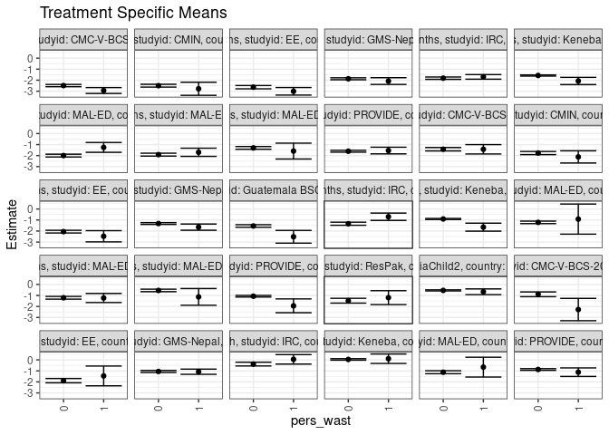

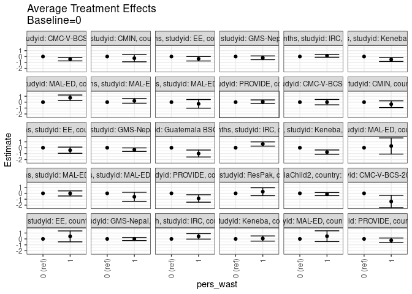

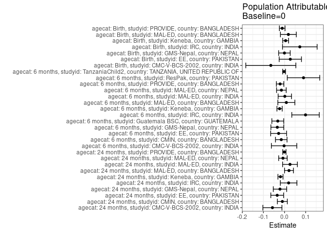

## Results Table

### Parameter: TSM

| agecat | studyid | country | intervention_level | baseline_level | estimate | ci_lower | ci_upper |
| --- | --- | --- | --- | --- | --- | --- | --- |
| Birth | CMC-V-BCS-2002 | INDIA | 0 | NA | -0.8962720 | -1.1105049 | -0.6820392 |
| Birth | CMC-V-BCS-2002 | INDIA | 1 | NA | -2.2806797 | -3.2937036 | -1.2676559 |
| Birth | EE | PAKISTAN | 0 | NA | -1.8881803 | -2.0824710 | -1.6938896 |
| Birth | EE | PAKISTAN | 1 | NA | -1.4585788 | -2.3561285 | -0.5610291 |
| Birth | GMS-Nepal | NEPAL | 0 | NA | -1.0549033 | -1.1468119 | -0.9629947 |
| Birth | GMS-Nepal | NEPAL | 1 | NA | -1.0776492 | -1.3139148 | -0.8413837 |
| Birth | IRC | INDIA | 0 | NA | -0.3840310 | -0.5558659 | -0.2121960 |
| Birth | IRC | INDIA | 1 | NA | 0.0467468 | -0.3833117 | 0.4768053 |
| Birth | Keneba | GAMBIA | 0 | NA | 0.0380485 | -0.0288996 | 0.1049966 |
| Birth | Keneba | GAMBIA | 1 | NA | 0.1039181 | -0.3248871 | 0.5327232 |
| Birth | MAL-ED | BANGLADESH | 0 | NA | -1.1222727 | -1.2564846 | -0.9880609 |
| Birth | MAL-ED | BANGLADESH | 1 | NA | -0.6600000 | -1.5592093 | 0.2392093 |
| Birth | PROVIDE | BANGLADESH | 0 | NA | -0.8740691 | -0.9514344 | -0.7967039 |
| Birth | PROVIDE | BANGLADESH | 1 | NA | -1.1185346 | -1.5073729 | -0.7296963 |
| 6 months | CMC-V-BCS-2002 | INDIA | 0 | NA | -1.4219998 | -1.5759366 | -1.2680631 |
| 6 months | CMC-V-BCS-2002 | INDIA | 1 | NA | -1.4273426 | -1.8534305 | -1.0012546 |
| 6 months | CMIN | BANGLADESH | 0 | NA | -1.7689321 | -1.9103576 | -1.6275067 |
| 6 months | CMIN | BANGLADESH | 1 | NA | -2.1178320 | -2.6714619 | -1.5642022 |
| 6 months | EE | PAKISTAN | 0 | NA | -2.0555424 | -2.1775400 | -1.9335447 |
| 6 months | EE | PAKISTAN | 1 | NA | -2.4737925 | -2.9830718 | -1.9645132 |
| 6 months | GMS-Nepal | NEPAL | 0 | NA | -1.3191111 | -1.4008637 | -1.2373584 |
| 6 months | GMS-Nepal | NEPAL | 1 | NA | -1.6462356 | -1.9289660 | -1.3635052 |
| 6 months | Guatemala BSC | GUATEMALA | 0 | NA | -1.5415418 | -1.6567941 | -1.4262896 |
| 6 months | Guatemala BSC | GUATEMALA | 1 | NA | -2.5211111 | -3.0985428 | -1.9436794 |
| 6 months | IRC | INDIA | 0 | NA | -1.3376858 | -1.4775035 | -1.1978682 |
| 6 months | IRC | INDIA | 1 | NA | -0.7032689 | -1.0345886 | -0.3719492 |
| 6 months | Keneba | GAMBIA | 0 | NA | -0.9047313 | -0.9536042 | -0.8558584 |
| 6 months | Keneba | GAMBIA | 1 | NA | -1.6497394 | -2.0112026 | -1.2882762 |
| 6 months | MAL-ED | BANGLADESH | 0 | NA | -1.2135826 | -1.3270160 | -1.1001493 |
| 6 months | MAL-ED | BANGLADESH | 1 | NA | -0.9178571 | -2.2823123 | 0.4465980 |
| 6 months | MAL-ED | INDIA | 0 | NA | -1.2128992 | -1.3370068 | -1.0887916 |
| 6 months | MAL-ED | INDIA | 1 | NA | -1.2325717 | -1.6458182 | -0.8193252 |
| 6 months | MAL-ED | NEPAL | 0 | NA | -0.5467101 | -0.6599035 | -0.4335168 |
| 6 months | MAL-ED | NEPAL | 1 | NA | -1.1316667 | -1.8892005 | -0.3741328 |
| 6 months | PROVIDE | BANGLADESH | 0 | NA | -1.0707341 | -1.1450735 | -0.9963947 |
| 6 months | PROVIDE | BANGLADESH | 1 | NA | -1.9422053 | -2.5686049 | -1.3158057 |
| 6 months | ResPak | PAKISTAN | 0 | NA | -1.4773041 | -1.6965255 | -1.2580826 |
| 6 months | ResPak | PAKISTAN | 1 | NA | -1.1993558 | -1.8293412 | -0.5693705 |
| 6 months | TanzaniaChild2 | TANZANIA, UNITED REPUBLIC OF | 0 | NA | -0.5428378 | -0.5927449 | -0.4929306 |
| 6 months | TanzaniaChild2 | TANZANIA, UNITED REPUBLIC OF | 1 | NA | -0.6663464 | -0.9248432 | -0.4078496 |
| 24 months | CMC-V-BCS-2002 | INDIA | 0 | NA | -2.4915642 | -2.5952284 | -2.3879000 |
| 24 months | CMC-V-BCS-2002 | INDIA | 1 | NA | -2.9386010 | -3.2060473 | -2.6711546 |
| 24 months | CMIN | BANGLADESH | 0 | NA | -2.5005794 | -2.6283894 | -2.3727694 |
| 24 months | CMIN | BANGLADESH | 1 | NA | -2.7794444 | -3.3734067 | -2.1854822 |
| 24 months | EE | PAKISTAN | 0 | NA | -2.6352445 | -2.7863284 | -2.4841605 |
| 24 months | EE | PAKISTAN | 1 | NA | -3.0084908 | -3.3524445 | -2.6645371 |
| 24 months | GMS-Nepal | NEPAL | 0 | NA | -1.8722277 | -1.9610523 | -1.7834030 |
| 24 months | GMS-Nepal | NEPAL | 1 | NA | -2.0818587 | -2.3878840 | -1.7758333 |
| 24 months | IRC | INDIA | 0 | NA | -1.8182857 | -1.9235374 | -1.7130339 |
| 24 months | IRC | INDIA | 1 | NA | -1.7008759 | -1.9084930 | -1.4932589 |
| 24 months | Keneba | GAMBIA | 0 | NA | -1.5731890 | -1.6274115 | -1.5189664 |
| 24 months | Keneba | GAMBIA | 1 | NA | -2.0733930 | -2.4008104 | -1.7459756 |
| 24 months | MAL-ED | BANGLADESH | 0 | NA | -1.9994417 | -2.1279716 | -1.8709119 |
| 24 months | MAL-ED | BANGLADESH | 1 | NA | -1.2558333 | -1.7012482 | -0.8104185 |
| 24 months | MAL-ED | INDIA | 0 | NA | -1.9120446 | -2.0430221 | -1.7810671 |
| 24 months | MAL-ED | INDIA | 1 | NA | -1.6972664 | -2.0702402 | -1.3242925 |
| 24 months | MAL-ED | NEPAL | 0 | NA | -1.2999550 | -1.4209558 | -1.1789541 |
| 24 months | MAL-ED | NEPAL | 1 | NA | -1.5900000 | -2.3102086 | -0.8697914 |
| 24 months | PROVIDE | BANGLADESH | 0 | NA | -1.6015761 | -1.6866932 | -1.5164591 |
| 24 months | PROVIDE | BANGLADESH | 1 | NA | -1.5404181 | -1.8437559 | -1.2370804 |

### Parameter: E(Y)

| agecat | studyid | country | intervention_level | baseline_level | estimate | ci_lower | ci_upper |
| --- | --- | --- | --- | --- | --- | --- | --- |
| Birth | CMC-V-BCS-2002 | INDIA | NA | NA | -0.9611957 | -1.1776967 | -0.7446946 |
| Birth | EE | PAKISTAN | NA | NA | -1.8608750 | -2.0482045 | -1.6735455 |
| Birth | GMS-Nepal | NEPAL | NA | NA | -1.0554530 | -1.1411259 | -0.9697801 |
| Birth | IRC | INDIA | NA | NA | -0.3117313 | -0.4727359 | -0.1507267 |
| Birth | Keneba | GAMBIA | NA | NA | 0.0432135 | -0.0229516 | 0.1093787 |
| Birth | MAL-ED | BANGLADESH | NA | NA | -1.1041048 | -1.2383048 | -0.9699048 |
| Birth | PROVIDE | BANGLADESH | NA | NA | -0.8851020 | -0.9601332 | -0.8100709 |
| 6 months | CMC-V-BCS-2002 | INDIA | NA | NA | -1.4241872 | -1.5668135 | -1.2815609 |
| 6 months | CMIN | BANGLADESH | NA | NA | -1.7844376 | -1.9222926 | -1.6465825 |
| 6 months | EE | PAKISTAN | NA | NA | -2.0835567 | -2.2027557 | -1.9643578 |
| 6 months | GMS-Nepal | NEPAL | NA | NA | -1.3533244 | -1.4319426 | -1.2747062 |
| 6 months | Guatemala BSC | GUATEMALA | NA | NA | -1.5734843 | -1.6884116 | -1.4585570 |
| 6 months | IRC | INDIA | NA | NA | -1.2382964 | -1.3698449 | -1.1067479 |
| 6 months | Keneba | GAMBIA | NA | NA | -0.9282048 | -0.9770928 | -0.8793169 |
| 6 months | MAL-ED | BANGLADESH | NA | NA | -1.2049931 | -1.3222136 | -1.0877726 |
| 6 months | MAL-ED | INDIA | NA | NA | -1.2115254 | -1.3298727 | -1.0931782 |
| 6 months | MAL-ED | NEPAL | NA | NA | -0.5615819 | -0.6741832 | -0.4489807 |
| 6 months | PROVIDE | BANGLADESH | NA | NA | -1.0916915 | -1.1661176 | -1.0172654 |
| 6 months | ResPak | PAKISTAN | NA | NA | -1.3874523 | -1.5959323 | -1.1789723 |
| 6 months | TanzaniaChild2 | TANZANIA, UNITED REPUBLIC OF | NA | NA | -0.5450830 | -0.5941754 | -0.4959906 |
| 24 months | CMC-V-BCS-2002 | INDIA | NA | NA | -2.5489071 | -2.6476125 | -2.4502017 |
| 24 months | CMIN | BANGLADESH | NA | NA | -2.5109504 | -2.6361514 | -2.3857494 |
| 24 months | EE | PAKISTAN | NA | NA | -2.6699900 | -2.8138051 | -2.5261749 |
| 24 months | GMS-Nepal | NEPAL | NA | NA | -1.8938622 | -1.9795205 | -1.8082040 |
| 24 months | IRC | INDIA | NA | NA | -1.7989338 | -1.8927769 | -1.7050907 |
| 24 months | Keneba | GAMBIA | NA | NA | -1.5924094 | -1.6461889 | -1.5386298 |
| 24 months | MAL-ED | BANGLADESH | NA | NA | -1.9783962 | -2.1050210 | -1.8517715 |
| 24 months | MAL-ED | INDIA | NA | NA | -1.8861894 | -2.0110006 | -1.7613783 |
| 24 months | MAL-ED | NEPAL | NA | NA | -1.3075877 | -1.4270718 | -1.1881037 |
| 24 months | PROVIDE | BANGLADESH | NA | NA | -1.6024221 | -1.6857420 | -1.5191023 |

### Parameter: ATE

| agecat | studyid | country | intervention_level | baseline_level | estimate | ci_lower | ci_upper |
| --- | --- | --- | --- | --- | --- | --- | --- |
| Birth | CMC-V-BCS-2002 | INDIA | 0 | 0 | 0.0000000 | 0.0000000 | 0.0000000 |
| Birth | CMC-V-BCS-2002 | INDIA | 1 | 0 | -1.3844077 | -2.4294281 | -0.3393874 |
| Birth | EE | PAKISTAN | 0 | 0 | 0.0000000 | 0.0000000 | 0.0000000 |
| Birth | EE | PAKISTAN | 1 | 0 | 0.4296015 | -0.4934558 | 1.3526589 |
| Birth | GMS-Nepal | NEPAL | 0 | 0 | 0.0000000 | 0.0000000 | 0.0000000 |
| Birth | GMS-Nepal | NEPAL | 1 | 0 | -0.0227459 | -0.2765530 | 0.2310611 |
| Birth | IRC | INDIA | 0 | 0 | 0.0000000 | 0.0000000 | 0.0000000 |
| Birth | IRC | INDIA | 1 | 0 | 0.4307777 | -0.0320402 | 0.8935957 |
| Birth | Keneba | GAMBIA | 0 | 0 | 0.0000000 | 0.0000000 | 0.0000000 |
| Birth | Keneba | GAMBIA | 1 | 0 | 0.0658696 | -0.3683410 | 0.5000802 |
| Birth | MAL-ED | BANGLADESH | 0 | 0 | 0.0000000 | 0.0000000 | 0.0000000 |
| Birth | MAL-ED | BANGLADESH | 1 | 0 | 0.4622727 | -0.4468973 | 1.3714428 |
| Birth | PROVIDE | BANGLADESH | 0 | 0 | 0.0000000 | 0.0000000 | 0.0000000 |
| Birth | PROVIDE | BANGLADESH | 1 | 0 | -0.2444655 | -0.6403824 | 0.1514514 |
| 6 months | CMC-V-BCS-2002 | INDIA | 0 | 0 | 0.0000000 | 0.0000000 | 0.0000000 |
| 6 months | CMC-V-BCS-2002 | INDIA | 1 | 0 | -0.0053428 | -0.4584983 | 0.4478128 |
| 6 months | CMIN | BANGLADESH | 0 | 0 | 0.0000000 | 0.0000000 | 0.0000000 |
| 6 months | CMIN | BANGLADESH | 1 | 0 | -0.3488999 | -0.9193731 | 0.2215733 |
| 6 months | EE | PAKISTAN | 0 | 0 | 0.0000000 | 0.0000000 | 0.0000000 |
| 6 months | EE | PAKISTAN | 1 | 0 | -0.4182502 | -0.9427678 | 0.1062675 |
| 6 months | GMS-Nepal | NEPAL | 0 | 0 | 0.0000000 | 0.0000000 | 0.0000000 |
| 6 months | GMS-Nepal | NEPAL | 1 | 0 | -0.3271245 | -0.6212150 | -0.0330341 |
| 6 months | Guatemala BSC | GUATEMALA | 0 | 0 | 0.0000000 | 0.0000000 | 0.0000000 |
| 6 months | Guatemala BSC | GUATEMALA | 1 | 0 | -0.9795693 | -1.5683905 | -0.3907481 |
| 6 months | IRC | INDIA | 0 | 0 | 0.0000000 | 0.0000000 | 0.0000000 |
| 6 months | IRC | INDIA | 1 | 0 | 0.6344169 | 0.2757900 | 0.9930439 |
| 6 months | Keneba | GAMBIA | 0 | 0 | 0.0000000 | 0.0000000 | 0.0000000 |
| 6 months | Keneba | GAMBIA | 1 | 0 | -0.7450081 | -1.1099900 | -0.3800263 |
| 6 months | MAL-ED | BANGLADESH | 0 | 0 | 0.0000000 | 0.0000000 | 0.0000000 |
| 6 months | MAL-ED | BANGLADESH | 1 | 0 | 0.2957255 | -1.0734367 | 1.6648877 |
| 6 months | MAL-ED | INDIA | 0 | 0 | 0.0000000 | 0.0000000 | 0.0000000 |
| 6 months | MAL-ED | INDIA | 1 | 0 | -0.0196725 | -0.4513988 | 0.4120539 |
| 6 months | MAL-ED | NEPAL | 0 | 0 | 0.0000000 | 0.0000000 | 0.0000000 |
| 6 months | MAL-ED | NEPAL | 1 | 0 | -0.5849565 | -1.3509005 | 0.1809875 |
| 6 months | PROVIDE | BANGLADESH | 0 | 0 | 0.0000000 | 0.0000000 | 0.0000000 |
| 6 months | PROVIDE | BANGLADESH | 1 | 0 | -0.8714712 | -1.5020594 | -0.2408830 |
| 6 months | ResPak | PAKISTAN | 0 | 0 | 0.0000000 | 0.0000000 | 0.0000000 |
| 6 months | ResPak | PAKISTAN | 1 | 0 | 0.2779482 | -0.3927241 | 0.9486206 |
| 6 months | TanzaniaChild2 | TANZANIA, UNITED REPUBLIC OF | 0 | 0 | 0.0000000 | 0.0000000 | 0.0000000 |
| 6 months | TanzaniaChild2 | TANZANIA, UNITED REPUBLIC OF | 1 | 0 | -0.1235086 | -0.3865772 | 0.1395599 |
| 24 months | CMC-V-BCS-2002 | INDIA | 0 | 0 | 0.0000000 | 0.0000000 | 0.0000000 |
| 24 months | CMC-V-BCS-2002 | INDIA | 1 | 0 | -0.4470368 | -0.7336523 | -0.1604214 |
| 24 months | CMIN | BANGLADESH | 0 | 0 | 0.0000000 | 0.0000000 | 0.0000000 |
| 24 months | CMIN | BANGLADESH | 1 | 0 | -0.2788650 | -0.8864229 | 0.3286928 |
| 24 months | EE | PAKISTAN | 0 | 0 | 0.0000000 | 0.0000000 | 0.0000000 |
| 24 months | EE | PAKISTAN | 1 | 0 | -0.3732463 | -0.7501394 | 0.0036467 |
| 24 months | GMS-Nepal | NEPAL | 0 | 0 | 0.0000000 | 0.0000000 | 0.0000000 |
| 24 months | GMS-Nepal | NEPAL | 1 | 0 | -0.2096310 | -0.5274077 | 0.1081457 |
| 24 months | IRC | INDIA | 0 | 0 | 0.0000000 | 0.0000000 | 0.0000000 |
| 24 months | IRC | INDIA | 1 | 0 | 0.1174097 | -0.1159560 | 0.3507755 |
| 24 months | Keneba | GAMBIA | 0 | 0 | 0.0000000 | 0.0000000 | 0.0000000 |
| 24 months | Keneba | GAMBIA | 1 | 0 | -0.5002040 | -0.8320916 | -0.1683164 |
| 24 months | MAL-ED | BANGLADESH | 0 | 0 | 0.0000000 | 0.0000000 | 0.0000000 |
| 24 months | MAL-ED | BANGLADESH | 1 | 0 | 0.7436084 | 0.2800199 | 1.2071969 |
| 24 months | MAL-ED | INDIA | 0 | 0 | 0.0000000 | 0.0000000 | 0.0000000 |
| 24 months | MAL-ED | INDIA | 1 | 0 | 0.2147782 | -0.1811126 | 0.6106690 |
| 24 months | MAL-ED | NEPAL | 0 | 0 | 0.0000000 | 0.0000000 | 0.0000000 |
| 24 months | MAL-ED | NEPAL | 1 | 0 | -0.2900450 | -1.0203475 | 0.4402574 |
| 24 months | PROVIDE | BANGLADESH | 0 | 0 | 0.0000000 | 0.0000000 | 0.0000000 |
| 24 months | PROVIDE | BANGLADESH | 1 | 0 | 0.0611580 | -0.2539896 | 0.3763055 |

### Parameter: PAR

| agecat | studyid | country | intervention_level | baseline_level | estimate | ci_lower | ci_upper |
| --- | --- | --- | --- | --- | --- | --- | --- |
| Birth | CMC-V-BCS-2002 | INDIA | 0 | NA | -0.0649236 | -0.1833814 | 0.0535341 |
| Birth | EE | PAKISTAN | 0 | NA | 0.0273053 | -0.0254376 | 0.0800483 |
| Birth | GMS-Nepal | NEPAL | 0 | NA | -0.0005497 | -0.0279691 | 0.0268698 |
| Birth | IRC | INDIA | 0 | NA | 0.0722997 | -0.0095802 | 0.1541796 |
| Birth | Keneba | GAMBIA | 0 | NA | 0.0051651 | -0.0086471 | 0.0189772 |
| Birth | MAL-ED | BANGLADESH | 0 | NA | 0.0181679 | -0.0194178 | 0.0557537 |
| Birth | PROVIDE | BANGLADESH | 0 | NA | -0.0110329 | -0.0242654 | 0.0021996 |
| 6 months | CMC-V-BCS-2002 | INDIA | 0 | NA | -0.0021874 | -0.0623513 | 0.0579765 |
| 6 months | CMIN | BANGLADESH | 0 | NA | -0.0155054 | -0.0427502 | 0.0117394 |
| 6 months | EE | PAKISTAN | 0 | NA | -0.0280144 | -0.0655961 | 0.0095673 |
| 6 months | GMS-Nepal | NEPAL | 0 | NA | -0.0342133 | -0.0646483 | -0.0037783 |
| 6 months | Guatemala BSC | GUATEMALA | 0 | NA | -0.0319425 | -0.0600761 | -0.0038089 |
| 6 months | IRC | INDIA | 0 | NA | 0.0993895 | 0.0343177 | 0.1644612 |
| 6 months | Keneba | GAMBIA | 0 | NA | -0.0234735 | -0.0358968 | -0.0110502 |
| 6 months | MAL-ED | BANGLADESH | 0 | NA | 0.0085895 | -0.0316719 | 0.0488510 |
| 6 months | MAL-ED | INDIA | 0 | NA | 0.0013738 | -0.0302962 | 0.0330438 |
| 6 months | MAL-ED | NEPAL | 0 | NA | -0.0148718 | -0.0376268 | 0.0078833 |
| 6 months | PROVIDE | BANGLADESH | 0 | NA | -0.0209574 | -0.0385880 | -0.0033268 |
| 6 months | ResPak | PAKISTAN | 0 | NA | 0.0898518 | 0.0130219 | 0.1666817 |
| 6 months | TanzaniaChild2 | TANZANIA, UNITED REPUBLIC OF | 0 | NA | -0.0022452 | -0.0089493 | 0.0044589 |
| 24 months | CMC-V-BCS-2002 | INDIA | 0 | NA | -0.0573429 | -0.1024385 | -0.0122474 |
| 24 months | CMIN | BANGLADESH | 0 | NA | -0.0103710 | -0.0339279 | 0.0131858 |
| 24 months | EE | PAKISTAN | 0 | NA | -0.0347455 | -0.0649670 | -0.0045241 |
| 24 months | GMS-Nepal | NEPAL | 0 | NA | -0.0216345 | -0.0533260 | 0.0100569 |
| 24 months | IRC | INDIA | 0 | NA | 0.0193519 | -0.0199009 | 0.0586046 |
| 24 months | Keneba | GAMBIA | 0 | NA | -0.0192204 | -0.0311559 | -0.0072849 |
| 24 months | MAL-ED | BANGLADESH | 0 | NA | 0.0210455 | -0.0001441 | 0.0422351 |
| 24 months | MAL-ED | INDIA | 0 | NA | 0.0258552 | -0.0091249 | 0.0608352 |
| 24 months | MAL-ED | NEPAL | 0 | NA | -0.0076328 | -0.0277780 | 0.0125124 |
| 24 months | PROVIDE | BANGLADESH | 0 | NA | -0.0008460 | -0.0085743 | 0.0068823 |